# Bhawnesh Dipu

- ***Email: bhawnesh.dipu@gmail.com***
- *Mobile: 7205772214*
- **Computer Science and Engineering**
- **National Institute of Science and Technology, Berhampur**

# Objective

- *To obtain a position of responsibilities that utilizes my skills and experience and keen to work in an environment where I can enrich my knowledge.*

# Academic Details

| YEAR | DEGREE | INSTITUTE | PERCENTAGE/CGPA |
| --- | --- | --- | --- |
| 2013-17 | B. Tech in Computer Science and Technology | National Institute of Science and Technology,Berhampur | CGPA: 8.28 / 10 |
| 2012 | Class XII (CBSE-AISSCE) | Central Hindu Boys School, Varanasi | 62.04% |
| 2010 | Class X (CBSE-AISSE) | D.A.V. Public School , Pusauli | CGPA : 9.20 / 10 |

# Major Projects

- *Data Viewpoints a Web based Mathematical Software for Data analysis .*
- *Restaurant Website with Admin Module for Dynamic Management of website Contents*
- *Web Scarapping in Python and Java using Selenium*
- *Question-Answering Bot with Admin module and Dashboard*.

# Mini Projects

- *Developed a Rat and Snake Game using C++.*
- *College Councelling Website*
- *Twitter OAuth1.0 Api Integration.*

# Workshops Attended

- *Two days’ Workshop on Autonomous Robot, SakRobotix Lab Pvt. Ltd., January 26-27,2016.*

# Summer Training Courses

- *Oracle 11g in Summer 2014 from National Institute of Science and Technology , Berhmapur.*
- *High Performance Computing from National Institute of Science and Technology , Berhmapur.*

# Achievements

- *Qualified for Facebook Hacker Cup 2015 Round 1 (username : bhawnesh.dipu)*
- *Qualified for Google CodeJam 2016 Round 1 (username:bhawnesh.dipu)*
- *Qualified for Codechef Snackdown 2015,2016 elimination (team: nist_404)*
- *Secured All India Rank 70 in Round-2, CodeVita-2016. (Team: nist404)*
- *Runner up in CodeRush (Over Night Coding Contest) in Sankalp-2015.*
- *Worked as Teacher Assistance in NIST during 4 th  Semester.*

# Computer Skills

- *Programming Languages:* *C/C++, Java , Python , PHP* .
- *Database:* *Oracle 11g, Mysql* .
- *Framework:* *Springboot, Laravel,Django*
- *Platforms:* *Linux and Windows*

# Position of Responsibility

- *Campus Ambassador of Hackerrank (online platform for coding) of NIST, Berhmapur*
- *Core Member of NIST Club Excel (Coding Club)*
- *Member of NIST STUDENT COUNSELLING SERVICES*

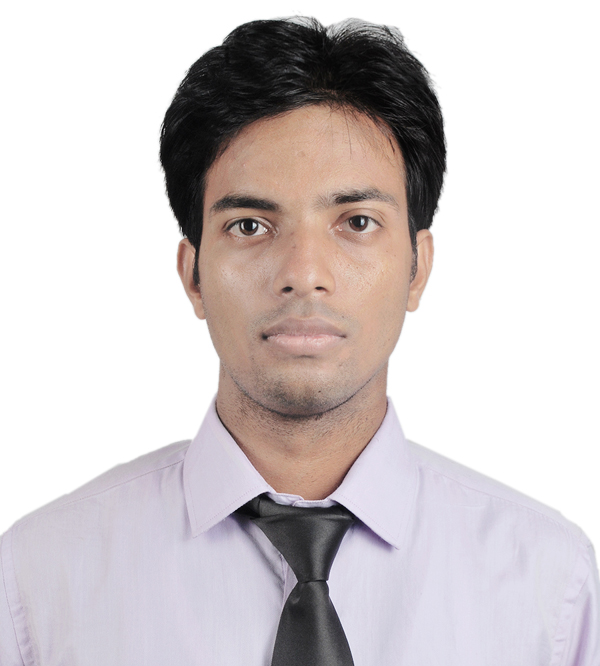